# Data Organisation and Introduction to R

Hugo Tavares (hugo.tavares@slcu.cam.ac.uk)  
7 Dec 2016

Cancer Research Uk Bioinformatics Winter School: Cambridge, 7th-9th December 2016

### Outline of Day 1

- Session 1 - Data Organisation (in spreadsheets)
- Session 2 - Introduction to R and Rstudio
- Session 3 - Data manipulation in R
- Session 4 - Data visualisation in R (short intro - more on Day 2)

We will use material from the lessons developed by the [Data Carpentry](http://www.datacarpentry.org/) initiative.

This is not a full Data Carpentry course, just a shortened version of it (but we do run these at the University, if you're interested).

### Data Organisation (in spreadsheets)

- Recognise and apply principles and good practices for organising your data
- Recognise common pitfalls when recording data (and learn to avoid them!)
- Understanding file formats and their suitability for other programs (e.g. R)

The material for this session is available from the Data Carpentry website ( [here](http://www.datacarpentry.org/spreadsheet-ecology-lesson/01-format-data.html)).

### Data Organisation - be cautious with dates

Let's say I recorded some collection dates in the form “Month-Day”.

I didn't bother with the year, because I know what year I'm in right now!

Input these data in a worksheet:

```
Feb-12
Mar-14
Apr-21
```

What Day, Month, Year is assumed by your spreadsheet program?

### Data Organisation - be cautious with dates

Be careful, different spreadsheet programs assume different things!

Even different versions of the same software might assume different things!

- To avoid problems, **store dates as separate variables with the Day, Month, Year**

More about dates [here](http://www.datacarpentry.org/spreadsheet-ecology-lesson/03-dates-as-data.html).

### Data Organisation - exporting data from spreadsheets

If possible, store/distribute data in `CSV` (comma-separated-values) format:

```
species,year,month,day,weight_kg,height_cm
mouse,2014,3,21,2,10
dog,2013,7,2,20,60
cat,2016,12,7,4.2,25
```

More about exporting data [here](http://www.datacarpentry.org/spreadsheet-ecology-lesson/05-exporting-data.html).

### Tea break and a stretch

### Introduction to R and Rstudio

- Getting to know Rstudio
- Learn basic syntax of R

The materials for this session are available from the Data Carpentry website (Lesson 1 [here](http://www.datacarpentry.org/R-ecology-lesson/)).

### Data manipulation in R

- Read data from a file
- Understand what factors are
- Understand how to manipulate a `data.frame` object
- Filter and summarise data

The materials for this session are available from the Data Carpentry website (Lessons 2-4 [here](http://www.datacarpentry.org/R-ecology-lesson/)).

### Data visualisation in R

- Learn about 3 types of plots: scatterplots, histograms, boxplots
- Make some customisations to produce clearer plots

We will no longer use the Data Carpentry lessons, because we will use `base` R graphics (the default in R).

However, if you want to learn about an alternative, please check the Data Carpentry [lesson](http://www.datacarpentry.org/R-ecology-lesson/05-visualization-ggplot2.html) on using the `ggplot2` package.

### Data visualisation in R

Make sure you have the `surveys` data in the right format (as detailed in [this lesson](http://www.datacarpentry.org/R-ecology-lesson/04-dplyr.html#exporting-data)):

```r
library(dplyr)
surveys_complete <- surveys %>%
  filter(species_id != "",         # remove missing species_id
         !is.na(weight),           # remove missing weight
         !is.na(hindfoot_length),  # remove missing hindfoot_length
         sex != "")                # remove missing sex

## Extract the most common species_id
species_counts <- surveys_complete %>%
                  group_by(species_id) %>%
                  tally %>%
                  filter(n >= 50) %>%
                  select(species_id)

## Only keep the most common species
surveys_complete <- surveys_complete %>%
                 filter(species_id %in% species_counts$species_id)
```

### Data visualisation in R - scatterplot

Let's say we want to see if there is a correlation between the animal's weight and its hindfoot length. We can use the `plot()` function for this, indicating what values we want to be assigned to the `x` and `y` axis.

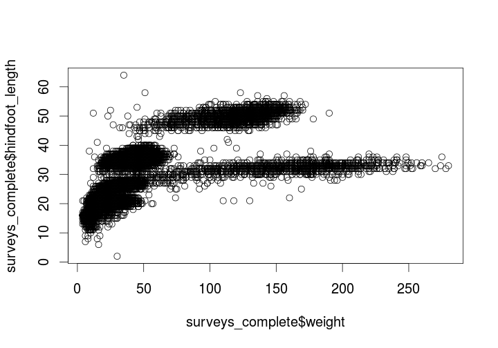

```r
plot(x = surveys_complete$weight, y = surveys_complete$hindfoot_length)
```

Challenge: how can we change the axis labels? Check the help for the function with `?plot`

### Data visualisation in R - scatterplot

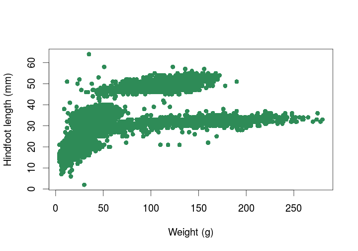

```r
plot(surveys_complete$weight, surveys_complete$hindfoot_length,
     xlab = "Weight (g)", ylab = "Hindfoot length (mm)",
     pch = 16, col = "seagreen")
```

What do the `pch` and `col` arguments do?

Many of these graphical parameters can be found in the `par` function. Check its help to see if you find what these arguments do.

### Data visualisation in R - histogram

We would like to know what kind of distribution our data follow.

A typical way to display this information is using a histogram:

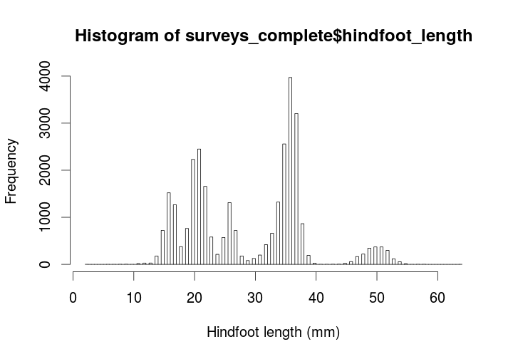

```r
hist(surveys_complete$hindfoot_length, breaks = 100, xlab = "Hindfoot length (mm)")
```

What does this distribution suggest?

### Data visualisation in R - boxplot

The syntax for this is special:

```r
boxplot(surveys_complete$hindfoot_length ~ surveys_complete$species_id)
```

We will learn more about the special '~' tomorrow, but for now it means that we want to plot the hindfoot length split by species id.

### Data visualisation in R - boxplot

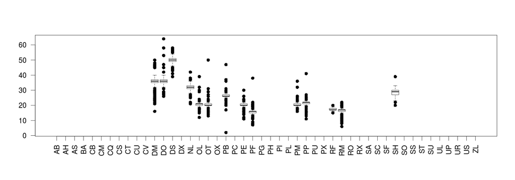

```r
boxplot(surveys_complete$hindfoot_length ~ surveys_complete$species_id, pch = 16, las = 2)
```

Why are there so many species with no data?

(also, notice the new `las` argument. Check `?par` to know more about it.)

### Data visualisation in R - boxplot

Even though we filtered our data earlier, the levels of our factor variables remained unchanged.

```r
levels(surveys_complete$species_id)
```

```
 [1] "AB" "AH" "AS" "BA" "CB" "CM" "CQ" "CS" "CT" "CU" "CV" "DM" "DO" "DS"
[15] "DX" "NL" "OL" "OT" "OX" "PB" "PC" "PE" "PF" "PG" "PH" "PI" "PL" "PM"
[29] "PP" "PU" "PX" "RF" "RM" "RO" "RX" "SA" "SC" "SF" "SH" "SO" "SS" "ST"
[43] "SU" "UL" "UP" "UR" "US" "ZL"
```

```r
levels(surveys$species_id)
```

```
 [1] "AB" "AH" "AS" "BA" "CB" "CM" "CQ" "CS" "CT" "CU" "CV" "DM" "DO" "DS"
[15] "DX" "NL" "OL" "OT" "OX" "PB" "PC" "PE" "PF" "PG" "PH" "PI" "PL" "PM"
[29] "PP" "PU" "PX" "RF" "RM" "RO" "RX" "SA" "SC" "SF" "SH" "SO" "SS" "ST"
[43] "SU" "UL" "UP" "UR" "US" "ZL"
```

### Data visualisation in R - boxplot

If we want to remove these levels, we can use the function `droplevels()`:

```r
surveys_complete <- droplevels(surveys_complete)
levels(surveys_complete$species_id)
```

```
 [1] "DM" "DO" "DS" "NL" "OL" "OT" "PB" "PE" "PF" "PM" "PP" "RF" "RM" "SH"
```

### Data visualisation in R - boxplot

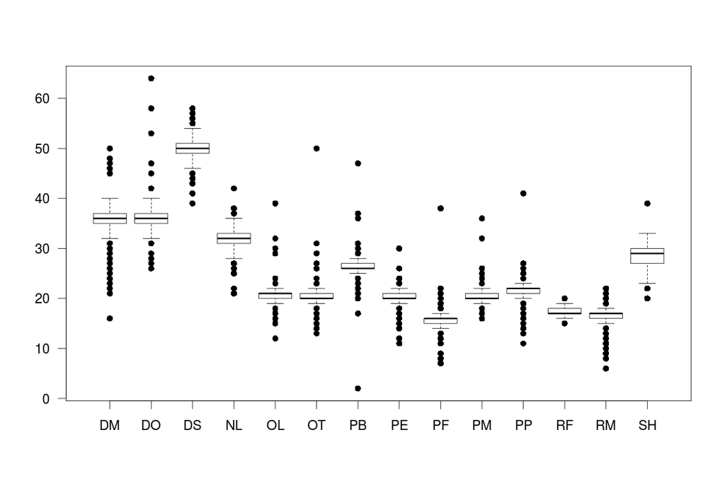

```r
boxplot(surveys_complete$hindfoot_length ~ surveys_complete$species_id, pch = 16, las = 1)
```